# Assignment 03 - Fitting and Validating Poisson Point Process Models

## Exercise 6 – 3 points

- Calculate the partial residuals as a function of both elevation and forest cover. – 1 point(s)
- Do you think that the terms are accurately capturing trends in the data? – 1 point(s)
- Do you have enough information to further refine the model and improve it’s accuracy? – 1 point(s)

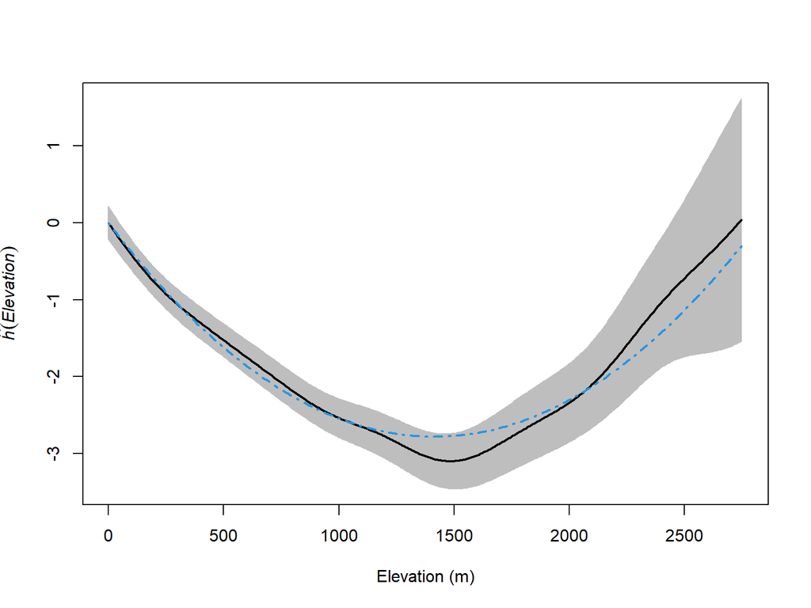

```r
# Calculate the partial residuals as a function of elevation
par_res_elev <- parres(fit, "Elevation")

# Calculate the relative intensity as a function of gradient
par_res_forest <- parres(fit, "Forest")

# Side by side plotting
plot(par_res_elev,
     legend = FALSE,
     lwd = 2,
     main = "",
     xlab = "Elevation (m)")
```

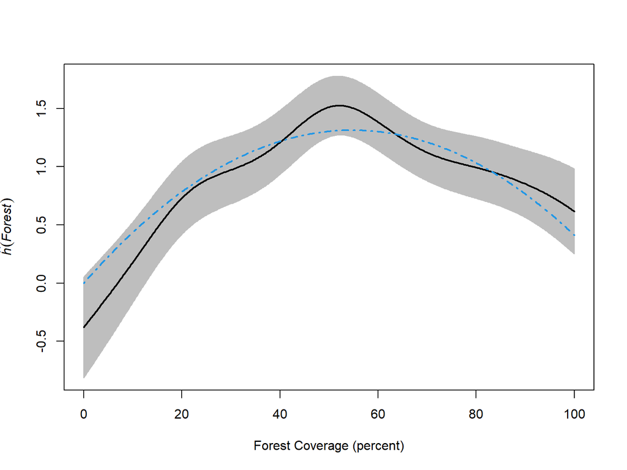

```r
plot(par_res_forest,
     legend = FALSE,
     lwd = 2,
     main = "",
     xlab = "Forest Coverage (percent)")
```

Based on the partial residual plots, it seems the terms are accurately capturing trends in the data, shown by the quadratic trend.

The elevation plot seems to do well and is mostly quadratic, however, based on the plots/information above, the forest coverage term can be improved by using a higher order polynomial rather than just a quadratic term to capture the complexities and it may be worth switching from a linear modelling framework to an additive modelling framework such as GAM’s.

## Exercise 7 – 1 points

- Based on these analyses, what have you learned about the spatial distribution of parks in BC? – 1 point(s)

The spatial distribution of BC parks share some sort of relationship with elevation and forest coverage across BC as shown by the above analysis.

In addition, we now have a model which is able to predict (to some degree) the intensity of BC parks for some given elevation and forest coverage percentage.